# Risk Factor Analysis

## Outcome Variable

**Outcome Variable:** y_rate_wtkg

## Predictor Variables

**Intervention Variable:** parity

**Adjustment Set:**

- arm
- W_mage
- meducyrs
- feducyrs
- W_mhtcm
- W_mwtkg
- W_mbmi
- vagbrth
- single
- delta_W_mage
- delta_meducyrs
- delta_feducyrs
- delta_W_mhtcm
- delta_W_mwtkg
- delta_W_mbmi
- delta_vagbrth
- delta_single

## Stratifying Variables

The analysis was stratified on these variable(s):

- agecat
- studyid
- country

## Data Summary

| agecat | studyid | country | parity | n_cell | n | outcome_variable |
| --- | --- | --- | --- | --- | --- | --- |
| 0-3 months | ki1000304b-SAS-CompFeed | INDIA | 1 | 346 | 1265 | y_rate_wtkg |
| 0-3 months | ki1000304b-SAS-CompFeed | INDIA | 2 | 300 | 1265 | y_rate_wtkg |
| 0-3 months | ki1000304b-SAS-CompFeed | INDIA | 3+ | 619 | 1265 | y_rate_wtkg |
| 0-3 months | ki1017093b-PROVIDE | BANGLADESH | 1 | 242 | 640 | y_rate_wtkg |
| 0-3 months | ki1017093b-PROVIDE | BANGLADESH | 2 | 226 | 640 | y_rate_wtkg |
| 0-3 months | ki1017093b-PROVIDE | BANGLADESH | 3+ | 172 | 640 | y_rate_wtkg |
| 0-3 months | ki1066203-TanzaniaChild2 | TANZANIA, UNITED REPUBLIC OF | 1 | 680 | 1996 | y_rate_wtkg |
| 0-3 months | ki1066203-TanzaniaChild2 | TANZANIA, UNITED REPUBLIC OF | 2 | 659 | 1996 | y_rate_wtkg |
| 0-3 months | ki1066203-TanzaniaChild2 | TANZANIA, UNITED REPUBLIC OF | 3+ | 657 | 1996 | y_rate_wtkg |
| 0-3 months | ki1101329-Keneba | GAMBIA | 1 | 192 | 1441 | y_rate_wtkg |
| 0-3 months | ki1101329-Keneba | GAMBIA | 2 | 149 | 1441 | y_rate_wtkg |
| 0-3 months | ki1101329-Keneba | GAMBIA | 3+ | 1100 | 1441 | y_rate_wtkg |
| 0-3 months | ki1113344-GMS-Nepal | NEPAL | 1 | 137 | 509 | y_rate_wtkg |
| 0-3 months | ki1113344-GMS-Nepal | NEPAL | 2 | 130 | 509 | y_rate_wtkg |
| 0-3 months | ki1113344-GMS-Nepal | NEPAL | 3+ | 242 | 509 | y_rate_wtkg |
| 0-3 months | ki1126311-ZVITAMBO | ZIMBABWE | 1 | 3175 | 8171 | y_rate_wtkg |
| 0-3 months | ki1126311-ZVITAMBO | ZIMBABWE | 2 | 2534 | 8171 | y_rate_wtkg |
| 0-3 months | ki1126311-ZVITAMBO | ZIMBABWE | 3+ | 2462 | 8171 | y_rate_wtkg |
| 0-3 months | ki1135781-COHORTS | GUATEMALA | 1 | 103 | 798 | y_rate_wtkg |
| 0-3 months | ki1135781-COHORTS | GUATEMALA | 2 | 114 | 798 | y_rate_wtkg |
| 0-3 months | ki1135781-COHORTS | GUATEMALA | 3+ | 581 | 798 | y_rate_wtkg |
| 0-3 months | ki1135781-COHORTS | INDIA | 1 | 713 | 4147 | y_rate_wtkg |
| 0-3 months | ki1135781-COHORTS | INDIA | 2 | 1045 | 4147 | y_rate_wtkg |
| 0-3 months | ki1135781-COHORTS | INDIA | 3+ | 2389 | 4147 | y_rate_wtkg |
| 0-3 months | kiGH5241-JiVitA-3 | BANGLADESH | 1 | 6551 | 20288 | y_rate_wtkg |
| 0-3 months | kiGH5241-JiVitA-3 | BANGLADESH | 2 | 6981 | 20288 | y_rate_wtkg |
| 0-3 months | kiGH5241-JiVitA-3 | BANGLADESH | 3+ | 6756 | 20288 | y_rate_wtkg |
| 3-6 months | ki1000304b-SAS-CompFeed | INDIA | 1 | 300 | 1118 | y_rate_wtkg |
| 3-6 months | ki1000304b-SAS-CompFeed | INDIA | 2 | 259 | 1118 | y_rate_wtkg |
| 3-6 months | ki1000304b-SAS-CompFeed | INDIA | 3+ | 559 | 1118 | y_rate_wtkg |

[output cut: 159 more lines]

The following strata were considered:

- agecat: 0-3 months, studyid: ki1000304b-SAS-CompFeed, country: INDIA
- agecat: 0-3 months, studyid: ki1017093b-PROVIDE, country: BANGLADESH
- agecat: 0-3 months, studyid: ki1066203-TanzaniaChild2, country: TANZANIA, UNITED REPUBLIC OF
- agecat: 0-3 months, studyid: ki1101329-Keneba, country: GAMBIA
- agecat: 0-3 months, studyid: ki1113344-GMS-Nepal, country: NEPAL
- agecat: 0-3 months, studyid: ki1126311-ZVITAMBO, country: ZIMBABWE
- agecat: 0-3 months, studyid: ki1135781-COHORTS, country: GUATEMALA
- agecat: 0-3 months, studyid: ki1135781-COHORTS, country: INDIA
- agecat: 0-3 months, studyid: kiGH5241-JiVitA-3, country: BANGLADESH
- agecat: 12-15 months, studyid: ki1000304b-SAS-CompFeed, country: INDIA
- agecat: 12-15 months, studyid: ki1000304b-SAS-FoodSuppl, country: INDIA
- agecat: 12-15 months, studyid: ki1017093b-PROVIDE, country: BANGLADESH
- agecat: 12-15 months, studyid: ki1066203-TanzaniaChild2, country: TANZANIA, UNITED REPUBLIC OF
- agecat: 12-15 months, studyid: ki1101329-Keneba, country: GAMBIA
- agecat: 12-15 months, studyid: ki1113344-GMS-Nepal, country: NEPAL
- agecat: 12-15 months, studyid: ki1126311-ZVITAMBO, country: ZIMBABWE
- agecat: 12-15 months, studyid: ki1135781-COHORTS, country: GUATEMALA
- agecat: 15-18 months, studyid: ki1000304b-SAS-CompFeed, country: INDIA
- agecat: 15-18 months, studyid: ki1000304b-SAS-FoodSuppl, country: INDIA
- agecat: 15-18 months, studyid: ki1017093b-PROVIDE, country: BANGLADESH
- agecat: 15-18 months, studyid: ki1066203-TanzaniaChild2, country: TANZANIA, UNITED REPUBLIC OF
- agecat: 15-18 months, studyid: ki1101329-Keneba, country: GAMBIA
- agecat: 15-18 months, studyid: ki1113344-GMS-Nepal, country: NEPAL
- agecat: 15-18 months, studyid: ki1126311-ZVITAMBO, country: ZIMBABWE
- agecat: 15-18 months, studyid: ki1135781-COHORTS, country: GUATEMALA
- agecat: 18-21 months, studyid: ki1017093b-PROVIDE, country: BANGLADESH
- agecat: 18-21 months, studyid: ki1066203-TanzaniaChild2, country: TANZANIA, UNITED REPUBLIC OF
- agecat: 18-21 months, studyid: ki1101329-Keneba, country: GAMBIA
- agecat: 18-21 months, studyid: ki1113344-GMS-Nepal, country: NEPAL
- agecat: 18-21 months, studyid: ki1126311-ZVITAMBO, country: ZIMBABWE
- agecat: 18-21 months, studyid: ki1135781-COHORTS, country: GUATEMALA
- agecat: 21-24 months, studyid: ki1017093b-PROVIDE, country: BANGLADESH
- agecat: 21-24 months, studyid: ki1101329-Keneba, country: GAMBIA
- agecat: 21-24 months, studyid: ki1113344-GMS-Nepal, country: NEPAL
- agecat: 21-24 months, studyid: ki1126311-ZVITAMBO, country: ZIMBABWE
- agecat: 21-24 months, studyid: ki1135781-COHORTS, country: GUATEMALA
- agecat: 3-6 months, studyid: ki1000304b-SAS-CompFeed, country: INDIA
- agecat: 3-6 months, studyid: ki1017093b-PROVIDE, country: BANGLADESH
- agecat: 3-6 months, studyid: ki1066203-TanzaniaChild2, country: TANZANIA, UNITED REPUBLIC OF
- agecat: 3-6 months, studyid: ki1101329-Keneba, country: GAMBIA
- agecat: 3-6 months, studyid: ki1113344-GMS-Nepal, country: NEPAL
- agecat: 3-6 months, studyid: ki1126311-ZVITAMBO, country: ZIMBABWE
- agecat: 3-6 months, studyid: ki1135781-COHORTS, country: GUATEMALA
- agecat: 3-6 months, studyid: ki1135781-COHORTS, country: INDIA
- agecat: 3-6 months, studyid: kiGH5241-JiVitA-3, country: BANGLADESH
- agecat: 6-9 months, studyid: ki1000304b-SAS-CompFeed, country: INDIA
- agecat: 6-9 months, studyid: ki1000304b-SAS-FoodSuppl, country: INDIA
- agecat: 6-9 months, studyid: ki1017093b-PROVIDE, country: BANGLADESH
- agecat: 6-9 months, studyid: ki1066203-TanzaniaChild2, country: TANZANIA, UNITED REPUBLIC OF
- agecat: 6-9 months, studyid: ki1101329-Keneba, country: GAMBIA
- agecat: 6-9 months, studyid: ki1113344-GMS-Nepal, country: NEPAL
- agecat: 6-9 months, studyid: ki1126311-ZVITAMBO, country: ZIMBABWE
- agecat: 6-9 months, studyid: ki1135781-COHORTS, country: GUATEMALA
- agecat: 6-9 months, studyid: ki1135781-COHORTS, country: INDIA
- agecat: 9-12 months, studyid: ki1000304b-SAS-CompFeed, country: INDIA
- agecat: 9-12 months, studyid: ki1000304b-SAS-FoodSuppl, country: INDIA
- agecat: 9-12 months, studyid: ki1017093b-PROVIDE, country: BANGLADESH
- agecat: 9-12 months, studyid: ki1066203-TanzaniaChild2, country: TANZANIA, UNITED REPUBLIC OF
- agecat: 9-12 months, studyid: ki1101329-Keneba, country: GAMBIA
- agecat: 9-12 months, studyid: ki1113344-GMS-Nepal, country: NEPAL
- agecat: 9-12 months, studyid: ki1126311-ZVITAMBO, country: ZIMBABWE
- agecat: 9-12 months, studyid: ki1135781-COHORTS, country: GUATEMALA
- agecat: 9-12 months, studyid: ki1135781-COHORTS, country: INDIA

### Dropped Strata

Some strata were dropped due to rare outcomes:

- agecat: 6-9 months, studyid: ki1000304b-SAS-FoodSuppl, country: INDIA
- agecat: 9-12 months, studyid: ki1000304b-SAS-FoodSuppl, country: INDIA
- agecat: 12-15 months, studyid: ki1000304b-SAS-FoodSuppl, country: INDIA
- agecat: 15-18 months, studyid: ki1000304b-SAS-FoodSuppl, country: INDIA
- agecat: 18-21 months, studyid: ki1066203-TanzaniaChild2, country: TANZANIA, UNITED REPUBLIC OF

## Methods Detail

We’re interested in the causal parameters $E[Y_a]$ for all values of $a \in \mathcal{A}$. These parameters represent the mean outcome if, possibly contrary to fact, we intervened to set all units to have $A=a$. Under the randomization and positivity assumptions, these are identified by the statistical parameters $\psi_a=E_W[E_{Y|A,W}(Y|A=a,W)]$. In addition, we’re interested in the mean of $Y$, $E[Y]$ under no intervention (the observed mean). We will estimate these parameters by using SuperLearner to fit the relevant likelihood factors – $E_{Y|A,W}(Y|A=a,W)$ and $p(A=a|W)$, and then updating our likelihood fit using a joint TMLE.

For unadjusted analyses ($W=\{\}$), initial likelihoods were estimated using Lrnr_glm to estimate the simple $E(Y|A)$ and Lrnr_mean to estimate $p(A)$. For adjusted analyses, a small library containing Lrnr_glmnet, Lrnr_xgboost, and Lrnr_mean was used.

Having estimated these parameters, we will then use the delta method to estimate relative risks and attributable risks relative to a prespecified baseline level of $A$.

# Results Detail

## Results Plots

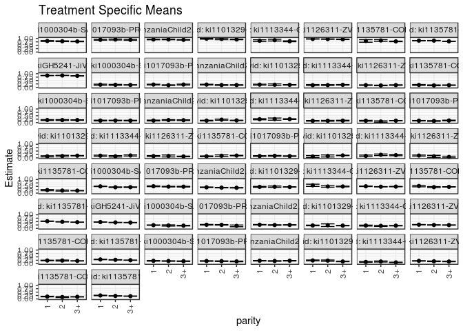

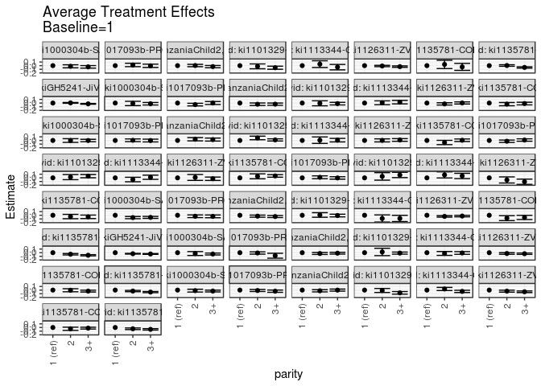

[figure not shown]

## Results Table

### Parameter: TSM

| agecat | studyid | country | intervention_level | baseline_level | estimate | ci_lower | ci_upper |
| --- | --- | --- | --- | --- | --- | --- | --- |
| 0-3 months | ki1000304b-SAS-CompFeed | INDIA | 1 | NA | 0.8144364 | 0.7736158 | 0.8552569 |
| 0-3 months | ki1000304b-SAS-CompFeed | INDIA | 2 | NA | 0.7958963 | 0.7681094 | 0.8236831 |
| 0-3 months | ki1000304b-SAS-CompFeed | INDIA | 3+ | NA | 0.7808745 | 0.7588518 | 0.8028973 |
| 0-3 months | ki1017093b-PROVIDE | BANGLADESH | 1 | NA | 0.9020938 | 0.8710803 | 0.9331072 |
| 0-3 months | ki1017093b-PROVIDE | BANGLADESH | 2 | NA | 0.9205705 | 0.8854238 | 0.9557172 |
| 0-3 months | ki1017093b-PROVIDE | BANGLADESH | 3+ | NA | 0.8977160 | 0.8643136 | 0.9311183 |
| 0-3 months | ki1066203-TanzaniaChild2 | TANZANIA, UNITED REPUBLIC OF | 1 | NA | 0.9250683 | 0.9020371 | 0.9480996 |
| 0-3 months | ki1066203-TanzaniaChild2 | TANZANIA, UNITED REPUBLIC OF | 2 | NA | 0.9282344 | 0.9055062 | 0.9509626 |
| 0-3 months | ki1066203-TanzaniaChild2 | TANZANIA, UNITED REPUBLIC OF | 3+ | NA | 0.8981467 | 0.8779621 | 0.9183312 |
| 0-3 months | ki1101329-Keneba | GAMBIA | 1 | NA | 0.9850668 | 0.9472193 | 1.0229144 |
| 0-3 months | ki1101329-Keneba | GAMBIA | 2 | NA | 0.9651924 | 0.9105105 | 1.0198743 |
| 0-3 months | ki1101329-Keneba | GAMBIA | 3+ | NA | 0.9277770 | 0.9081830 | 0.9473710 |
| 0-3 months | ki1113344-GMS-Nepal | NEPAL | 1 | NA | 0.8336010 | 0.7659470 | 0.9012550 |
| 0-3 months | ki1113344-GMS-Nepal | NEPAL | 2 | NA | 0.8746336 | 0.8118185 | 0.9374486 |
| 0-3 months | ki1113344-GMS-Nepal | NEPAL | 3+ | NA | 0.7924883 | 0.7601411 | 0.8248355 |
| 0-3 months | ki1126311-ZVITAMBO | ZIMBABWE | 1 | NA | 0.9631005 | 0.9504599 | 0.9757412 |
| 0-3 months | ki1126311-ZVITAMBO | ZIMBABWE | 2 | NA | 0.9532760 | 0.9399629 | 0.9665892 |
| 0-3 months | ki1126311-ZVITAMBO | ZIMBABWE | 3+ | NA | 0.9357090 | 0.9198984 | 0.9515196 |
| 0-3 months | ki1135781-COHORTS | GUATEMALA | 1 | NA | 0.8178251 | 0.7240529 | 0.9115973 |
| 0-3 months | ki1135781-COHORTS | GUATEMALA | 2 | NA | 0.8515857 | 0.7874618 | 0.9157096 |
| 0-3 months | ki1135781-COHORTS | GUATEMALA | 3+ | NA | 0.7829403 | 0.7618313 | 0.8040493 |
| 0-3 months | ki1135781-COHORTS | INDIA | 1 | NA | 0.8388934 | 0.8228939 | 0.8548929 |
| 0-3 months | ki1135781-COHORTS | INDIA | 2 | NA | 0.8420773 | 0.8277415 | 0.8564131 |
| 0-3 months | ki1135781-COHORTS | INDIA | 3+ | NA | 0.7898359 | 0.7811497 | 0.7985221 |
| 0-3 months | kiGH5241-JiVitA-3 | BANGLADESH | 1 | NA | 0.8665687 | 0.8580402 | 0.8750972 |
| 0-3 months | kiGH5241-JiVitA-3 | BANGLADESH | 2 | NA | 0.8710872 | 0.8645613 | 0.8776130 |
| 0-3 months | kiGH5241-JiVitA-3 | BANGLADESH | 3+ | NA | 0.8444917 | 0.8370580 | 0.8519255 |
| 3-6 months | ki1000304b-SAS-CompFeed | INDIA | 1 | NA | 0.4958915 | 0.4826283 | 0.5091546 |
| 3-6 months | ki1000304b-SAS-CompFeed | INDIA | 2 | NA | 0.4318309 | 0.4057424 | 0.4579194 |
| 3-6 months | ki1000304b-SAS-CompFeed | INDIA | 3+ | NA | 0.4380865 | 0.4148398 | 0.4613332 |

[output cut: 144 more lines]

### Parameter: E(Y)

| agecat | studyid | country | intervention_level | baseline_level | estimate | ci_lower | ci_upper |
| --- | --- | --- | --- | --- | --- | --- | --- |
| 0-3 months | ki1000304b-SAS-CompFeed | INDIA | NA | NA | 0.7908355 | 0.7705160 | 0.8111550 |
| 0-3 months | ki1017093b-PROVIDE | BANGLADESH | NA | NA | 0.9016472 | 0.8868914 | 0.9164029 |
| 0-3 months | ki1066203-TanzaniaChild2 | TANZANIA, UNITED REPUBLIC OF | NA | NA | 0.9222782 | 0.9120605 | 0.9324960 |
| 0-3 months | ki1101329-Keneba | GAMBIA | NA | NA | 0.9250728 | 0.9133367 | 0.9368088 |
| 0-3 months | ki1113344-GMS-Nepal | NEPAL | NA | NA | 0.8270122 | 0.8100415 | 0.8439828 |
| 0-3 months | ki1126311-ZVITAMBO | ZIMBABWE | NA | NA | 0.9497140 | 0.9445866 | 0.9548414 |
| 0-3 months | ki1135781-COHORTS | GUATEMALA | NA | NA | 0.7980090 | 0.7812054 | 0.8148126 |
| 0-3 months | ki1135781-COHORTS | INDIA | NA | NA | 0.8079112 | 0.8020259 | 0.8137966 |
| 0-3 months | kiGH5241-JiVitA-3 | BANGLADESH | NA | NA | 0.8576797 | 0.8546652 | 0.8606941 |
| 3-6 months | ki1000304b-SAS-CompFeed | INDIA | NA | NA | 0.4502075 | 0.4368094 | 0.4636057 |
| 3-6 months | ki1017093b-PROVIDE | BANGLADESH | NA | NA | 0.4890611 | 0.4760060 | 0.5021163 |
| 3-6 months | ki1066203-TanzaniaChild2 | TANZANIA, UNITED REPUBLIC OF | NA | NA | 0.4202993 | 0.4115402 | 0.4290585 |
| 3-6 months | ki1101329-Keneba | GAMBIA | NA | NA | 0.4451759 | 0.4348013 | 0.4555506 |
| 3-6 months | ki1113344-GMS-Nepal | NEPAL | NA | NA | 0.4976117 | 0.4838029 | 0.5114205 |
| 3-6 months | ki1126311-ZVITAMBO | ZIMBABWE | NA | NA | 0.4783450 | 0.4738196 | 0.4828705 |
| 3-6 months | ki1135781-COHORTS | GUATEMALA | NA | NA | 0.4605000 | 0.4496523 | 0.4713476 |
| 3-6 months | ki1135781-COHORTS | INDIA | NA | NA | 0.4724963 | 0.4676809 | 0.4773116 |
| 3-6 months | kiGH5241-JiVitA-3 | BANGLADESH | NA | NA | 0.4413738 | 0.4384031 | 0.4443445 |
| 6-9 months | ki1000304b-SAS-CompFeed | INDIA | NA | NA | 0.2097690 | 0.1949147 | 0.2246234 |
| 6-9 months | ki1017093b-PROVIDE | BANGLADESH | NA | NA | 0.2491653 | 0.2371134 | 0.2612172 |
| 6-9 months | ki1066203-TanzaniaChild2 | TANZANIA, UNITED REPUBLIC OF | NA | NA | 0.2555255 | 0.2465533 | 0.2644978 |
| 6-9 months | ki1101329-Keneba | GAMBIA | NA | NA | 0.2054643 | 0.1921119 | 0.2188168 |
| 6-9 months | ki1113344-GMS-Nepal | NEPAL | NA | NA | 0.1874500 | 0.1753777 | 0.1995223 |
| 6-9 months | ki1126311-ZVITAMBO | ZIMBABWE | NA | NA | 0.2583530 | 0.2538536 | 0.2628524 |
| 6-9 months | ki1135781-COHORTS | GUATEMALA | NA | NA | 0.2137898 | 0.2041068 | 0.2234728 |
| 6-9 months | ki1135781-COHORTS | INDIA | NA | NA | 0.2666046 | 0.2615353 | 0.2716740 |
| 9-12 months | ki1000304b-SAS-CompFeed | INDIA | NA | NA | 0.1943224 | 0.1874198 | 0.2012249 |
| 9-12 months | ki1017093b-PROVIDE | BANGLADESH | NA | NA | 0.1775316 | 0.1681968 | 0.1868664 |
| 9-12 months | ki1066203-TanzaniaChild2 | TANZANIA, UNITED REPUBLIC OF | NA | NA | 0.2048196 | 0.1946367 | 0.2150025 |
| 9-12 months | ki1101329-Keneba | GAMBIA | NA | NA | 0.1627974 | 0.1505170 | 0.1750777 |
| 9-12 months | ki1113344-GMS-Nepal | NEPAL | NA | NA | 0.1439907 | 0.1312935 | 0.1566879 |
| 9-12 months | ki1126311-ZVITAMBO | ZIMBABWE | NA | NA | 0.1800863 | 0.1755557 | 0.1846170 |
| 9-12 months | ki1135781-COHORTS | GUATEMALA | NA | NA | 0.1559960 | 0.1474406 | 0.1645514 |
| 9-12 months | ki1135781-COHORTS | INDIA | NA | NA | 0.2135824 | 0.2082338 | 0.2189309 |
| 12-15 months | ki1000304b-SAS-CompFeed | INDIA | NA | NA | 0.1851225 | 0.1777268 | 0.1925183 |
| 12-15 months | ki1017093b-PROVIDE | BANGLADESH | NA | NA | 0.1800324 | 0.1683272 | 0.1917375 |
| 12-15 months | ki1066203-TanzaniaChild2 | TANZANIA, UNITED REPUBLIC OF | NA | NA | 0.1741189 | 0.1626692 | 0.1855686 |
| 12-15 months | ki1101329-Keneba | GAMBIA | NA | NA | 0.1824116 | 0.1716763 | 0.1931470 |
| 12-15 months | ki1113344-GMS-Nepal | NEPAL | NA | NA | 0.1721075 | 0.1589812 | 0.1852337 |
| 12-15 months | ki1126311-ZVITAMBO | ZIMBABWE | NA | NA | 0.1499254 | 0.1419751 | 0.1578757 |
| 12-15 months | ki1135781-COHORTS | GUATEMALA | NA | NA | 0.1508808 | 0.1417226 | 0.1600389 |
| 15-18 months | ki1000304b-SAS-CompFeed | INDIA | NA | NA | 0.1775870 | 0.1644275 | 0.1907466 |
| 15-18 months | ki1017093b-PROVIDE | BANGLADESH | NA | NA | 0.1563514 | 0.1445823 | 0.1681205 |
| 15-18 months | ki1066203-TanzaniaChild2 | TANZANIA, UNITED REPUBLIC OF | NA | NA | 0.1694110 | 0.1549701 | 0.1838520 |
| 15-18 months | ki1101329-Keneba | GAMBIA | NA | NA | 0.1607263 | 0.1498189 | 0.1716337 |
| 15-18 months | ki1113344-GMS-Nepal | NEPAL | NA | NA | 0.2347736 | 0.2195239 | 0.2500233 |
| 15-18 months | ki1126311-ZVITAMBO | ZIMBABWE | NA | NA | 0.1337260 | 0.1231139 | 0.1443380 |
| 15-18 months | ki1135781-COHORTS | GUATEMALA | NA | NA | 0.1402124 | 0.1291753 | 0.1512496 |
| 18-21 months | ki1017093b-PROVIDE | BANGLADESH | NA | NA | 0.1324882 | 0.1210438 | 0.1439326 |
| 18-21 months | ki1101329-Keneba | GAMBIA | NA | NA | 0.1560829 | 0.1446249 | 0.1675408 |
| 18-21 months | ki1113344-GMS-Nepal | NEPAL | NA | NA | 0.1423948 | 0.1268654 | 0.1579242 |
| 18-21 months | ki1126311-ZVITAMBO | ZIMBABWE | NA | NA | 0.1209531 | 0.1039197 | 0.1379866 |
| 18-21 months | ki1135781-COHORTS | GUATEMALA | NA | NA | 0.1633163 | 0.1526500 | 0.1739826 |
| 21-24 months | ki1017093b-PROVIDE | BANGLADESH | NA | NA | 0.1419705 | 0.1305335 | 0.1534075 |
| 21-24 months | ki1101329-Keneba | GAMBIA | NA | NA | 0.1676062 | 0.1561278 | 0.1790846 |
| 21-24 months | ki1113344-GMS-Nepal | NEPAL | NA | NA | 0.1768175 | 0.1523979 | 0.2012370 |
| 21-24 months | ki1126311-ZVITAMBO | ZIMBABWE | NA | NA | 0.1090935 | 0.0811882 | 0.1369987 |
| 21-24 months | ki1135781-COHORTS | GUATEMALA | NA | NA | 0.1840047 | 0.1740929 | 0.1939165 |

### Parameter: ATE

| agecat | studyid | country | intervention_level | baseline_level | estimate | ci_lower | ci_upper |
| --- | --- | --- | --- | --- | --- | --- | --- |
| 0-3 months | ki1000304b-SAS-CompFeed | INDIA | 1 | 1 | 0.0000000 | 0.0000000 | 0.0000000 |
| 0-3 months | ki1000304b-SAS-CompFeed | INDIA | 2 | 1 | -0.0185401 | -0.0599945 | 0.0229143 |
| 0-3 months | ki1000304b-SAS-CompFeed | INDIA | 3+ | 1 | -0.0335618 | -0.0679931 | 0.0008694 |
| 0-3 months | ki1017093b-PROVIDE | BANGLADESH | 1 | 1 | 0.0000000 | 0.0000000 | 0.0000000 |
| 0-3 months | ki1017093b-PROVIDE | BANGLADESH | 2 | 1 | 0.0184767 | -0.0282904 | 0.0652439 |
| 0-3 months | ki1017093b-PROVIDE | BANGLADESH | 3+ | 1 | -0.0043778 | -0.0498030 | 0.0410474 |
| 0-3 months | ki1066203-TanzaniaChild2 | TANZANIA, UNITED REPUBLIC OF | 1 | 1 | 0.0000000 | 0.0000000 | 0.0000000 |
| 0-3 months | ki1066203-TanzaniaChild2 | TANZANIA, UNITED REPUBLIC OF | 2 | 1 | 0.0031661 | -0.0293034 | 0.0356356 |
| 0-3 months | ki1066203-TanzaniaChild2 | TANZANIA, UNITED REPUBLIC OF | 3+ | 1 | -0.0269217 | -0.0576676 | 0.0038242 |
| 0-3 months | ki1101329-Keneba | GAMBIA | 1 | 1 | 0.0000000 | 0.0000000 | 0.0000000 |
| 0-3 months | ki1101329-Keneba | GAMBIA | 2 | 1 | -0.0198744 | -0.0864249 | 0.0466760 |
| 0-3 months | ki1101329-Keneba | GAMBIA | 3+ | 1 | -0.0572898 | -0.0999433 | -0.0146363 |
| 0-3 months | ki1113344-GMS-Nepal | NEPAL | 1 | 1 | 0.0000000 | 0.0000000 | 0.0000000 |
| 0-3 months | ki1113344-GMS-Nepal | NEPAL | 2 | 1 | 0.0410325 | -0.0513969 | 0.1334620 |
| 0-3 months | ki1113344-GMS-Nepal | NEPAL | 3+ | 1 | -0.0411127 | -0.1161777 | 0.0339523 |
| 0-3 months | ki1126311-ZVITAMBO | ZIMBABWE | 1 | 1 | 0.0000000 | 0.0000000 | 0.0000000 |
| 0-3 months | ki1126311-ZVITAMBO | ZIMBABWE | 2 | 1 | -0.0098245 | -0.0281711 | 0.0085221 |
| 0-3 months | ki1126311-ZVITAMBO | ZIMBABWE | 3+ | 1 | -0.0273915 | -0.0476224 | -0.0071606 |
| 0-3 months | ki1135781-COHORTS | GUATEMALA | 1 | 1 | 0.0000000 | 0.0000000 | 0.0000000 |
| 0-3 months | ki1135781-COHORTS | GUATEMALA | 2 | 1 | 0.0337606 | -0.0799244 | 0.1474457 |
| 0-3 months | ki1135781-COHORTS | GUATEMALA | 3+ | 1 | -0.0348848 | -0.1310514 | 0.0612818 |
| 0-3 months | ki1135781-COHORTS | INDIA | 1 | 1 | 0.0000000 | 0.0000000 | 0.0000000 |
| 0-3 months | ki1135781-COHORTS | INDIA | 2 | 1 | 0.0031839 | -0.0182968 | 0.0246646 |
| 0-3 months | ki1135781-COHORTS | INDIA | 3+ | 1 | -0.0490576 | -0.0672599 | -0.0308552 |
| 0-3 months | kiGH5241-JiVitA-3 | BANGLADESH | 1 | 1 | 0.0000000 | 0.0000000 | 0.0000000 |
| 0-3 months | kiGH5241-JiVitA-3 | BANGLADESH | 2 | 1 | 0.0045185 | -0.0066766 | 0.0157136 |
| 0-3 months | kiGH5241-JiVitA-3 | BANGLADESH | 3+ | 1 | -0.0220769 | -0.0331301 | -0.0110237 |
| 3-6 months | ki1000304b-SAS-CompFeed | INDIA | 1 | 1 | 0.0000000 | 0.0000000 | 0.0000000 |
| 3-6 months | ki1000304b-SAS-CompFeed | INDIA | 2 | 1 | -0.0640606 | -0.0947436 | -0.0333776 |
| 3-6 months | ki1000304b-SAS-CompFeed | INDIA | 3+ | 1 | -0.0578050 | -0.0849600 | -0.0306500 |

[output cut: 144 more lines]

### Parameter: PAR

| agecat | studyid | country | intervention_level | baseline_level | estimate | ci_lower | ci_upper |
| --- | --- | --- | --- | --- | --- | --- | --- |
| 0-3 months | ki1000304b-SAS-CompFeed | INDIA | 1 | NA | -0.0236009 | -0.0549600 | 0.0077582 |
| 0-3 months | ki1017093b-PROVIDE | BANGLADESH | 1 | NA | -0.0004466 | -0.0277459 | 0.0268527 |
| 0-3 months | ki1066203-TanzaniaChild2 | TANZANIA, UNITED REPUBLIC OF | 1 | NA | -0.0027901 | -0.0235763 | 0.0179961 |
| 0-3 months | ki1101329-Keneba | GAMBIA | 1 | NA | -0.0599940 | -0.0973854 | -0.0226026 |
| 0-3 months | ki1113344-GMS-Nepal | NEPAL | 1 | NA | -0.0065889 | -0.0708054 | 0.0576277 |
| 0-3 months | ki1126311-ZVITAMBO | ZIMBABWE | 1 | NA | -0.0133865 | -0.0251060 | -0.0016670 |
| 0-3 months | ki1135781-COHORTS | GUATEMALA | 1 | NA | -0.0198161 | -0.1113417 | 0.0717096 |
| 0-3 months | ki1135781-COHORTS | INDIA | 1 | NA | -0.0309822 | -0.0463020 | -0.0156624 |
| 0-3 months | kiGH5241-JiVitA-3 | BANGLADESH | 1 | NA | -0.0088890 | -0.0170841 | -0.0006939 |
| 3-6 months | ki1000304b-SAS-CompFeed | INDIA | 1 | NA | -0.0456839 | -0.0621948 | -0.0291730 |
| 3-6 months | ki1017093b-PROVIDE | BANGLADESH | 1 | NA | -0.0154298 | -0.0413417 | 0.0104821 |
| 3-6 months | ki1066203-TanzaniaChild2 | TANZANIA, UNITED REPUBLIC OF | 1 | NA | -0.0077190 | -0.0266614 | 0.0112235 |
| 3-6 months | ki1101329-Keneba | GAMBIA | 1 | NA | -0.0138746 | -0.0471606 | 0.0194114 |
| 3-6 months | ki1113344-GMS-Nepal | NEPAL | 1 | NA | -0.0781355 | -0.1576706 | 0.0013996 |
| 3-6 months | ki1126311-ZVITAMBO | ZIMBABWE | 1 | NA | -0.0230277 | -0.0395707 | -0.0064847 |
| 3-6 months | ki1135781-COHORTS | GUATEMALA | 1 | NA | -0.0589838 | -0.1134684 | -0.0044992 |
| 3-6 months | ki1135781-COHORTS | INDIA | 1 | NA | -0.0535485 | -0.0675988 | -0.0394983 |
| 3-6 months | kiGH5241-JiVitA-3 | BANGLADESH | 1 | NA | -0.0236774 | -0.0307943 | -0.0165604 |
| 6-9 months | ki1000304b-SAS-CompFeed | INDIA | 1 | NA | -0.0293364 | -0.0527576 | -0.0059152 |
| 6-9 months | ki1017093b-PROVIDE | BANGLADESH | 1 | NA | -0.0185234 | -0.0401171 | 0.0030704 |
| 6-9 months | ki1066203-TanzaniaChild2 | TANZANIA, UNITED REPUBLIC OF | 1 | NA | -0.0141169 | -0.0297008 | 0.0014670 |
| 6-9 months | ki1101329-Keneba | GAMBIA | 1 | NA | -0.0108763 | -0.0363861 | 0.0146334 |
| 6-9 months | ki1113344-GMS-Nepal | NEPAL | 1 | NA | -0.0206330 | -0.0534017 | 0.0121358 |
| 6-9 months | ki1126311-ZVITAMBO | ZIMBABWE | 1 | NA | -0.0149318 | -0.0290019 | -0.0008618 |
| 6-9 months | ki1135781-COHORTS | GUATEMALA | 1 | NA | -0.0190170 | -0.0401925 | 0.0021585 |
| 6-9 months | ki1135781-COHORTS | INDIA | 1 | NA | -0.0416548 | -0.0545705 | -0.0287392 |
| 9-12 months | ki1000304b-SAS-CompFeed | INDIA | 1 | NA | -0.0135831 | -0.0404940 | 0.0133278 |
| 9-12 months | ki1017093b-PROVIDE | BANGLADESH | 1 | NA | -0.0163355 | -0.0338217 | 0.0011507 |
| 9-12 months | ki1066203-TanzaniaChild2 | TANZANIA, UNITED REPUBLIC OF | 1 | NA | -0.0104563 | -0.0278875 | 0.0069749 |
| 9-12 months | ki1101329-Keneba | GAMBIA | 1 | NA | -0.0725070 | -0.1053180 | -0.0396959 |
| 9-12 months | ki1113344-GMS-Nepal | NEPAL | 1 | NA | 0.0173007 | -0.0062593 | 0.0408608 |
| 9-12 months | ki1126311-ZVITAMBO | ZIMBABWE | 1 | NA | -0.0229346 | -0.0392949 | -0.0065743 |
| 9-12 months | ki1135781-COHORTS | GUATEMALA | 1 | NA | -0.0168612 | -0.0380782 | 0.0043559 |
| 9-12 months | ki1135781-COHORTS | INDIA | 1 | NA | -0.0404257 | -0.0572688 | -0.0235825 |
| 12-15 months | ki1000304b-SAS-CompFeed | INDIA | 1 | NA | -0.0087634 | -0.0474414 | 0.0299147 |
| 12-15 months | ki1017093b-PROVIDE | BANGLADESH | 1 | NA | -0.0214033 | -0.0439937 | 0.0011871 |
| 12-15 months | ki1066203-TanzaniaChild2 | TANZANIA, UNITED REPUBLIC OF | 1 | NA | -0.0257449 | -0.0456928 | -0.0057971 |
| 12-15 months | ki1101329-Keneba | GAMBIA | 1 | NA | -0.0138253 | -0.0460101 | 0.0183596 |
| 12-15 months | ki1113344-GMS-Nepal | NEPAL | 1 | NA | 0.0151496 | -0.0267493 | 0.0570485 |
| 12-15 months | ki1126311-ZVITAMBO | ZIMBABWE | 1 | NA | -0.0122820 | -0.0309008 | 0.0063369 |
| 12-15 months | ki1135781-COHORTS | GUATEMALA | 1 | NA | -0.0224778 | -0.0540472 | 0.0090917 |
| 15-18 months | ki1000304b-SAS-CompFeed | INDIA | 1 | NA | -0.0096771 | -0.0383085 | 0.0189544 |
| 15-18 months | ki1017093b-PROVIDE | BANGLADESH | 1 | NA | 0.0085382 | -0.0169799 | 0.0340562 |
| 15-18 months | ki1066203-TanzaniaChild2 | TANZANIA, UNITED REPUBLIC OF | 1 | NA | 0.0192376 | -0.0076168 | 0.0460920 |
| 15-18 months | ki1101329-Keneba | GAMBIA | 1 | NA | 0.0159513 | -0.0110830 | 0.0429855 |
| 15-18 months | ki1113344-GMS-Nepal | NEPAL | 1 | NA | -0.0121016 | -0.0503358 | 0.0261327 |
| 15-18 months | ki1126311-ZVITAMBO | ZIMBABWE | 1 | NA | 0.0046381 | -0.0172442 | 0.0265204 |
| 15-18 months | ki1135781-COHORTS | GUATEMALA | 1 | NA | 0.0053624 | -0.0251430 | 0.0358677 |
| 18-21 months | ki1017093b-PROVIDE | BANGLADESH | 1 | NA | -0.0065695 | -0.0242972 | 0.0111581 |
| 18-21 months | ki1101329-Keneba | GAMBIA | 1 | NA | 0.0453453 | 0.0030771 | 0.0876135 |
| 18-21 months | ki1113344-GMS-Nepal | NEPAL | 1 | NA | -0.0153470 | -0.0533584 | 0.0226644 |
| 18-21 months | ki1126311-ZVITAMBO | ZIMBABWE | 1 | NA | -0.0063638 | -0.0411890 | 0.0284614 |
| 18-21 months | ki1135781-COHORTS | GUATEMALA | 1 | NA | 0.0512756 | 0.0220676 | 0.0804836 |
| 21-24 months | ki1017093b-PROVIDE | BANGLADESH | 1 | NA | 0.0094662 | -0.0149800 | 0.0339124 |
| 21-24 months | ki1101329-Keneba | GAMBIA | 1 | NA | 0.0699500 | 0.0002121 | 0.1396878 |
| 21-24 months | ki1113344-GMS-Nepal | NEPAL | 1 | NA | 0.0335344 | -0.0257571 | 0.0928258 |
| 21-24 months | ki1126311-ZVITAMBO | ZIMBABWE | 1 | NA | -0.0589921 | -0.0948143 | -0.0231698 |
| 21-24 months | ki1135781-COHORTS | GUATEMALA | 1 | NA | -0.0395448 | -0.0843289 | 0.0052392 |